# Mundo de Wumpus

Projeto para Inteligência Computacional

# Introdução

## Contextualização

O projeto foi desenvolvido com base no clássico jogo de computador chamado Mundo de Wumpus. Neste jogo, o agente explora uma caverna composta por compartimentos conectados por passagens. Um desses compartimentos contém o Wumpus, um temível monstro que devora qualquer um que entre em seu espaço. Além disso, alguns compartimentos possuem abismos que engolem qualquer pessoa que os adentre, exceto o Wumpus, que é grande demais para cair. A única motivação do agente para permanecer nesse ambiente perigoso é a busca pelo tesouro. O agente tem a capacidade de atirar uma flecha para tentar matar o Wumpus, mas só possui uma chance.

## Justificativa

O projeto do Mundo de Wumpus visa proporciona aos estudantes da disciplina de Inteligência Computacional uma oportunidade de aplicar conceitos e técnicas de inteligência artificial em um ambiente desafiador, estimulando o raciocínio lógico, a resolução de problemas e o desenvolvimento de habilidades práticas. Ele oferece uma experiência enriquecedora que fortalecerá o aprendizado dos alunos e sua compreensão dos princípios fundamentais da inteligência computacional.

## Objetivos

Os objetivos que o projeto proposto busca alcançar são:

- Compreender os conceitos de agentes inteligentes;
- Desenvolver habilidades de resolução de problemas;
- Explorar técnicas de inteligência artificial; e
- Promover o raciocínio lógico e a tomada de decisões inteligentes.

# Metodologia

O desenvolvimento do projeto foi organizado em etapas para a implementação das técnicas abordadas durante as aulas da disciplina de Inteligência Computacional.

O projeto foi concebido e implementado utilizando a linguagem de programação Python, aproveitando suas capacidades e bibliotecas relevantes para a construção dos códigos necessários. Essa abordagem permitiu explorar os conceitos teóricos estudados na disciplina por meio de aplicações práticas no Mundo de Wumpus.

## Etapa 1 - Gerador aleatório de ambientes do Mundo de Wumpus

Nesta etapa do projeto, abordamos a criação de um gerador de ambientes aleatório para o mundo de Wumpus. As configurações utilizadas para a criação do ambiente foram definidas e estão apresentadas na Tabela 1.

**Tabela 1 - Configurações do ambiente do Mundo de Wumpus.**

| Tamanho | Objetos | Percepções |
| --- | --- | --- |
| Matriz quadrada | Poços (-1) | Brisa |
| Ordem 3 | Wumpus (-2) | Fedor |
| Linha e coluna = (n-1) | Ouro (1) | Brilho |

Além disso, existem algumas restrições que devem ser observadas durante a elaboração do cenário, tais como: a casa inicial do agente deve estar livre de qualquer objeto, e nos locais onde houver poços, não é permitido posicionar o ouro nem o Wumpus. No entanto, o ouro e o Wumpus podem ser posicionados em qualquer outra casa do ambiente.

No código disponibilizado no [GitHub](https://github.com/cotabr/Mundo-de-Wumpus/tree/main), são definidos o tamanho do tabuleiro, a quantidade de buracos, Wumpus e tesouros.

### Parâmetros Iniciais:

```
has_treasure = False  # Variável para controlar se o agente pegou o tesouro
has_arrow = True  # Variável para controlar se o agente tem uma flecha
```

Essas variáveis são usadas para controlar o estado do agente em relação ao tesouro e à flecha.

### Função `generate_board`:

```
def generate_board(size, num_pits, num_wumpus, num_treasure):
    # Cria a matriz preenchida com zeros
    nmatrix = np.zeros((size, size))

    # Define a posição inicial do agente
    agent_pos = (size - 1, 0)
    nmatrix[agent_pos] = 2  # 2 representa o agente

    # Define a posição aleatória dos buracos
    for _ in range(num_pits):
        while True:
            row, col = random.randrange(size), random.randrange(size)
            if nmatrix[row][col] == 0 and (row, col) != agent_pos:
                nmatrix[row][col] = -1  # -1 representa um buraco
                break

    # Define a posição aleatória do Wumpus
    for _ in range(num_wumpus):
        while True:
            row, col = random.randrange(size), random.randrange(size)
            if nmatrix[row][col] == 0 and (row, col) != agent_pos:
                nmatrix[row][col] = -2  # -2 representa o Wumpus
                break

    # Define a posição aleatória do tesouro
    for _ in range(num_treasure):
        while True:
            row, col = random.randrange(size), random.randrange(size)
            if nmatrix[row][col] == 0 and (row, col) != agent_pos:
                nmatrix[row][col] = 1  # 1 representa o tesouro
                break

    return nmatrix, agent_pos
```

A função generate_board recebe o tamanho do tabuleiro (`size`) e o número de buracos (`num_pits`), Wumpus (`num_wumpus`) e tesouros (`num_treasure`) como parâmetros. Ela gera um tabuleiro aleatório preenchido com valores numéricos, representando o agente, buracos, Wumpus e tesouros. O agente é inicializado na posição inferior esquerda do tabuleiro.

### Função `get_perceptions`:

```
def get_perceptions(agent_pos, matrix):
    perceptions = []
    row, col = agent_pos
    size = matrix.shape[0]
    directions = [(0, -1), (0, 1), (-1, 0), (1, 0)]  # esquerda, direita, acima, abaixo

    for dx, dy in directions:
        new_row, new_col = row + dx, col + dy

        if 0 <= new_row < size and 0 <= new_col < size:
            if matrix[new_row][new_col] == -1:
                perceptions.append("brisa")
            elif matrix[new_row][new_col] == -2:
                perceptions.append("fedor")

    if matrix[row][col] == 1:
        if not has_treasure:  # Verifica se o agente ainda não pegou o tesouro
            perceptions.append("brilho")

    return perceptions
```

A função `get_perceptions` recebe a posição do agente e a matriz do tabuleiro como parâmetros. Ela verifica as percepções ao redor do agente (como brisa, fedor e brilho) com base nos valores presentes na matriz do tabuleiro. As percepções são armazenadas em uma lista e retornadas pela função.

### Função `define_action`:

```
def define_action(agent_pos, matrix):
    perceptions = get_perceptions(agent_pos, matrix)
    if {"fedor", "brisa", "brilho"} <= set(perceptions):
        return "mover", "pegar", "atirar"
    elif {"fedor", "brisa"} <= set(perceptions):
        return "mover", "atirar"
    elif {"fedor", "brilho"} <= set(perceptions):
        return "mover", "pegar"
    elif set(perceptions) == {"fedor"}:
        return "atirar", "mover"
    elif set(perceptions) == {"brisa"}:
        return "mover"
    elif set(perceptions) == {"brilho"}:
        return "pegar"
    else:
        return "mover"
```

A função `define_action` recebe a posição do agente e a matriz do tabuleiro como parâmetros. Com base nas percepções obtidas por get_perceptions, ela define a ação ou conjunto de ações possíveis para o agente. As ações são determinadas pelas combinações de percepções e retornadas como uma sequência de strings.

### Função `print_agent_position`:

```
def print_agent_position(agent_pos):
    row, col = agent_pos
    print(f"Nova posição do agente: ({row}, {col})")
```

A função `print_agent_position` recebe a posição do agente como parâmetro e imprime a nova posição na saída.

A etapa 1 da metodologia apresenta o gerador de ambientes aleatório para o mundo de Wumpus. O código implementa funções para gerar um tabuleiro aleatório com buracos, Wumpus e tesouros, obter percepções ao redor do agente, definir a ação com base nas percepções e imprimir a nova posição do agente. Essas funções são usadas posteriormente nas etapas subsequentes do projeto.

## Etapa 2 - Agente reativo (versão 1)

Nesta etapa do projeto, apresentamos o agente reativo inicial, que toma decisões de forma aleatória sem considerar nenhum conhecimento sobre o ambiente.

Para definir as regras do agente, foi criada uma [Tabela](https://docs.google.com/spreadsheets/d/1P9ERyc96ZGstzZdIpT79o8C-XpIPPAhLF2d93hOksVY/edit?usp=sharing) que relaciona as percepções do ambiente com as ações a serem tomadas. A tabela é utilizada para orientar o comportamento do agente, permitindo que ele tome decisões com base nas informações sensoriais que recebe.

### Parâmetros do Tabuleiro:

```
size = 3
num_pits = 2
num_wumpus = 1
num_treasure = 1
```

Aqui, definimos os parâmetros do tabuleiro.

### Variáveis Contadoras:

```
total_movimentos = 0
total_mortes = 0
total_ouros = 0
total_wumpus = 0
total_vitorias = 0
```

Essas variáveis são usadas para contar e rastrear estatísticas sobre os resultados dos jogos.

### Loop Principal dos Jogos:

```
for _ in range(num_jogos):
    # ...
```

Aqui, iniciamos um loop que executa o número de jogos especificado em `num_jogos`. Cada iteração desse loop representa um jogo do agente.

### Reinicializar o Jogo:

```
board, agent_pos = generate_board(size, num_pits, num_wumpus, num_treasure)
```

Antes de cada jogo, reinicializamos o jogo gerando um novo tabuleiro usando a função `generate_board()` e obtendo a posição inicial do agente.

### Reiniciar as Variáveis de Estado:

```
has_treasure = False
has_arrow = True
```

Aqui, reiniciamos as variáveis de estado do agente, como `has_treasure` (indicando se o agente tem o tesouro) e `has_arrow` (indicando se o agente tem uma flecha).

### Loop Principal do Jogo:

```
while True:
    # Estratégia adotada para escolher a ação

    action_def = define_action(agent_pos, matrix)
    if type(action_def) == str:
        action_sort = action_def
    else:
        action_sort = random.choice(action_def)

    # Ação de atirar escolhida

    if action_sort == "atirar":
        # ...

    # Ação de mover escolhida

    if action_sort == "mover":
        # ...
```

Dentro do loop principal do jogo, o agente adota uma estratégia de escolha de ação. A função `define_action()` retorna uma ação ou uma lista de ações possíveis para o agente. Em seguida, o agente seleciona aleatoriamente uma ação usando `random.choice(action_def)`, conforme segue:

- Ação de Atirar: Se a ação selecionada for “atirar”, o agente verifica se tem uma flecha disponível (`has_arrow`). Em seguida, seleciona aleatoriamente uma direção usando `random.choice(directions)` para atirar. Se a posição alvo contiver um Wumpus, o agente acerta o alvo, remove o agente e o Wumpus da sala e incrementa a contagem de Wumpus mortos. Caso contrário, o agente apenas exibe uma mensagem informando que atirou, mas não acertou o Wumpus; e
- Ação de Mover: Se a ação selecionada for “mover”, o agente executa a lógica para se mover. O agente escolhe aleatoriamente uma direção usando `random.choice(directions)` e verifica se a nova posição é válida. Se a nova posição contiver um buraco ou um Wumpus, o agente morre e a contagem de mortes é incrementada. Caso contrário, se a nova posição contiver um tesouro e o agente ainda não tiver o tesouro, o agente pega o tesouro, incrementa a contagem de ouros e atualiza a matriz do tabuleiro. Em seguida, o agente atualiza sua posição, exibe a nova posição e incrementa a contagem de movimentos.

### Verificar Vitória:

```
if has_treasure and agent_pos == (size - 1, 0):
    print("Parabéns! O agente venceu o jogo!")
    total_vitorias += 1
    break
```

O agente verifica se tem o tesouro (`has_treasure`) e se chegou à posição de saída (`(size - 1, 0)`) para determinar se venceu o jogo. Se essa condição for verdadeira, o agente exibe uma mensagem de vitória, incrementa a contagem de vitórias e encerra o jogo.

### Exibição dos Resultados:

```
print("Resultados do teste de validação:")
print("Total de jogos:", num_jogos)
print("Total de movimentos:", total_movimentos)
print("Total de mortes:", total_mortes)
print("Total de ouros pegos:", total_ouros)
print("Total de Wumpus mortos:", total_wumpus)
print("Total de vitórias:", total_vitorias)
```

No final dos jogos, são exibidos os resultados do teste de validação, contendo o número total de jogos, o total de movimentos, o total de mortes, o total de ouros pegos, o total de Wumpus mortos e o total de vitórias.

A etapa 2 apresenta a implementação do agente reativo inicial, que toma decisões de forma aleatória sem utilizar nenhum conhecimento sobre o ambiente. O agente realiza ações de acordo com a estratégia adotada, como atirar aleatoriamente ou se mover aleatoriamente. Os resultados são contabilizados e exibidos ao final do teste de validação.

## Etapa 3 - Agente reativo (versão 2)

Nesta etapa do projeto, apresentamos um agente reativo melhorado que utiliza uma memória para tomar decisões mais informadas. A memória do agente é atualizada a cada jogada com as percepções do ambiente e armazena informações relevantes para tomar decisões futuras.

### Criação da instância da classe `Memory`:

```
memory = Memory()
```

Aqui, criamos uma instância da classe Memory que será responsável por armazenar as informações relevantes sobre o ambiente.

### Atualização das percepções na memória:

```
memory.update_perceptions(agent_pos, get_perceptions(agent_pos, matrix))
```

Após cada jogada, as percepções do agente são atualizadas usando a função `get_perceptions(agent_pos, matrix)`. Em seguida, as percepções são passadas para o método `update_perceptions()` da classe `Memory`, juntamente com a posição atual do agente (`agent_pos`), para atualizar a memória com as informações mais recentes.

### Utilização da memória para decidir a ação:

```
action = choose_action(agent_pos, memory)
```

Após a atualização da memória, o agente utiliza a memória para tomar uma decisão sobre qual ação realizar. A função `choose_action(agent_pos, memory)` é responsável por tomar a decisão com base nas informações contidas na memória.

### Ação de Atirar:

```
if action_sort == "atirar":
    # Verificar se há um Wumpus em qualquer direção
    wumpus_hit = False

    # Selecionar uma direção aleatória
    dx, dy = random.choice(directions)

    # ...
```

Se a ação selecionada for “atirar”, o agente verifica se tem uma flecha disponível (has_arrow). Em seguida, seleciona aleatoriamente uma direção usando `random.choice(directions)` para atirar. Se a posição alvo contiver um Wumpus, o agente acerta o alvo, remove o agente e o Wumpus da sala e incrementa a contagem de Wumpus mortos. Caso contrário, o agente apenas exibe uma mensagem informando que atirou, mas não acertou o Wumpus.

### Ação de Mover:

```
if action_sort == "mover":
    # Lógica para mover o agente

    unvisited_moves = []

    for dx, dy in directions:
        # ...

    if unvisited_moves:
        dx, dy = random.choice(unvisited_moves)
    else:
        dx, dy = random.choice(directions)

    # ...
```

Se a ação selecionada for “mover”, o agente executa a lógica para decidir para onde se mover. Primeiro, o agente verifica se já pegou o tesouro e se ainda não chegou à posição de saída (`has_treasure` e `exit_pos`). Se essas condições forem atendidas, o agente se moverá em direção à posição de saída. Caso contrário, o agente verifica as salas vizinhas para encontrar movimentos não visitados. Essas informações são obtidas através do loop `for dx, dy in directions`. Se houver movimentos não visitados, o agente selecionará um deles aleatoriamente usando`random.choice(unvisited_moves)`. Caso contrário, o agente selecionará uma direção aleatória usando `random.choice(directions)`. Em seguida, o agente se move para a nova posição, atualiza a matriz do tabuleiro e incrementa a contagem de movimentos.

### Outras Considerações:

```
if has_treasure == True and agent_pos != exit_pos:
  # Agente tem o tesouro e ainda não chegou à posição de saída
  # Movimento em direção à posição de saída
  for i in range(len(passos_agente) - 1, -1, -1):
      row, col = passos_agente[i]
      # Limpa a posição atual
      matrix[agent_pos[0]][agent_pos[1]] = 0
      agent_pos = (row, col)
      # Define a nova posição do agente
      matrix[agent_pos[0]][agent_pos[1]] = 2
      print_agent_position(agent_pos)
      total_movimentos += 1
```

Esse trecho de código permite que o agente, caso já tenha pegado o tesouro e ainda não tenha chegado à posição de saída, refaça os passos anteriores para voltar à posição inicial. O agente percorre os passos registrados na lista `passos_agente`, atualizando sua posição na matriz matrix e exibindo a nova posição. Isso é feito para que o agente possa retornar ao início do labirinto e ganhar o jogo.

O código também possui as implementações para atualização das variáveis de contagem, tratamento de vitória, morte e exibição dos resultados finais do teste de validação.

A etapa 3 apresenta a implementação do agente reativo melhorado com memória, que utiliza as informações armazenadas na memória para tomar decisões mais informadas sobre as ações a serem executadas. Com a utilização da memória, o agente pode aprender com as experiências anteriores e melhorar seu desempenho no ambiente do Mundo de Wumpus.

## Etapa 4 - Agente de aprendizagem

Na última etapa do projeto, foi desenvolvido um agente de aprendizagem. Esse agente é capaz de aprender e aprimorar seu desempenho ao longo do tempo por meio de técnicas de aprendizado de máquina ou algoritmos de inteligência artificial. O agente utiliza dados coletados do ambiente para ajustar suas estratégias e otimizar suas decisões. No entanto, esta parte não foi codificada, permanecendo apenas o projeto.

### Codificação do Indivíduo

Cada indivíduo da população será representado por uma sequência de ações que o agente pode executar, como “mover”, “pegar” e “atirar”. Essas sequências de ações formam um cromossomo, onde cada gene representa uma ação possível. A população inicial será gerada aleatoriamente, com cada indivíduo contendo uma sequência de ações variada.

### Avaliação de Fitness

A função de avaliação de fitness é essencial para determinar quão bem cada indivíduo está desempenhando no jogo. Neste caso, o fitness pode ser calculado considerando diversos critérios, como a quantidade de ouros coletados, a quantidade de Wumpus mortos e a quantidade de vezes que o agente conseguiu sair com o ouro. Quanto maior o fitness, melhor o desempenho do indivíduo.

### Seleção

A seleção é a etapa em que os indivíduos com maior fitness têm maior probabilidade de serem escolhidos para reprodução. Diferentes métodos de seleção podem ser utilizados, como a seleção por roleta ou o torneio. Essa etapa garante que os indivíduos mais aptos tenham maior chance de transmitir suas características para as próximas gerações.

### Cruzamento e Mutação

O cruzamento é o processo de combinação dos genes dos pais selecionados para gerar novos indivíduos. Um ponto de corte aleatório é escolhido na sequência de ações dos pais, e os genes são trocados a partir desse ponto, gerando novos indivíduos chamados filhos. A mutação é um operador genético que introduz pequenas alterações nos genes dos filhos para garantir a diversidade genética da população.

### Substituição da População

Após o cruzamento e a mutação, uma nova população é formada pelos filhos gerados. Essa nova população substitui a população anterior, garantindo a evolução do algoritmo genético ao longo das gerações. O processo de seleção, cruzamento e mutação é repetido até que uma condição de parada seja atingida, como um número máximo de gerações ou um fitness alvo.

# Resultados

A etapa 1 do projeto foi responsável por gerar o ambiente do Mundo de Wumpus. Nessa etapa, foi permitido ao usuário definir a quantidade de objetos presentes no ambiente, como ouros, buracos e Wumpus. O tabuleiro resultante desse processo de geração do ambiente pode ser visualizado na Tabela 2. Nele, estão representados os diferentes elementos, como o agente, o ouro, os buracos e os Wumpus, de acordo com as configurações definidas pelo usuário.

Ordem 9

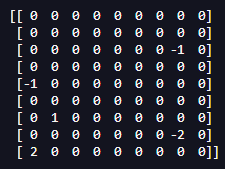

[output not shown]

Essas etapas iniciais foram fundamentais para criar um ambiente personalizado e fornecer as percepções necessárias para que o agente possa interagir com o Mundo de Wumpus de forma inteligente.

Na etapa 2 do projeto, foi implementada a movimentação do agente pelo tabuleiro do Mundo de Wumpus. Nessa etapa inicial, as ações do agente eram definidas de forma aleatória, ou seja, o agente realizava movimentos com base em regras pré-estabelecidas, mas sem avaliar as consequências daquela ação. O objetivo dessa abordagem era avaliar o desempenho do agente nessas condições iniciais.

Foram conduzidos testes de validação para avaliar o desempenho do agente ao realizar essas ações aleatórias. A Tabela 4 apresenta os resultados obtidos com base nos números de jogos realizados. Nesses testes, foram registrados dados importantes, como o número total de jogos, o número de movimentos realizados pelo agente, a quantidade de mortes ocorridas, o número de ouros coletados e o número de vitórias, ou seja, casos em que o agente conseguiu sair do ambiente com o ouro.

**Tabela 4 - Resultados para 30, 50 e 100 jogos.**

| Nº de Jogos | Movimentos | Mortes | Ouros | Wumpus Mortos | Vitórias |
| --- | --- | --- | --- | --- | --- |
| 30 | 95 | 24 | 15 | 4 | 6 |
| 50 | 117 | 45 | 11 | 2 | 5 |
| 100 | 255 | 88 | 27 | 8 | 12 |

Esses resultados preliminares permitem realizar uma primeira análise do desempenho do agente quando suas ações são tomadas de forma aleatória. Com base nesses dados, é possível constatar que a estratégia adotada se mostra pouco eficiente para atingir os objetivos do jogo.

Ao examinarmos os resultados dessa análise, torna-se evidente que o agente enfrenta dificuldades significativas ao tentar alcançar o sucesso em suas missões. Os dados revelam uma taxa média de sucesso extremamente baixa, registrando apenas 14%, enquanto a taxa de mortes é surpreendentemente alta, atingindo 86%. Esses números destacam o desafio enfrentado pelo agente em chegar à saída mesmo após ter obtido o tesouro. Ainda há uma baixa probabilidade de concluir a missão com êxito, indicando a necessidade de aprimorar suas estratégias e tomar decisões mais eficientes para alcançar seus objetivos.

Com o objetivo de aprimorar as chances de sucesso do agente no mundo do jogo do Wumpus, foram implementadas melhorias significativas na etapa 3, conforme detalhado na Metodologia do trabalho. Essas melhorias visavam proporcionar ao agente uma maior capacidade de tomar decisões mais inteligentes e estratégicas.

Os resultados obtidos a partir dessas melhorias são apresentados na Tabela 5.

**Tabela 5 - Resultados para 30, 50 e 100 jogos.**

| Nº de Jogos | Movimentos | Mortes | Ouros | Wumpus Mortos | Vitórias |
| --- | --- | --- | --- | --- | --- |
| 30 | 248 | 18 | 12 | 1 | 12 |
| 50 | 307 | 37 | 13 | 3 | 13 |
| 100 | 649 | 75 | 25 | 7 | 25 |

Ao analisar os resultados da Tabela 5, podemos observar uma melhoria em relação à Tabela 4. O número de movimentos aumentou, indicando que o agente está explorando mais o ambiente em busca do tesouro e da saída. Além disso, houve uma redução no número de mortes, o que sugere que o agente está tomando decisões mais cautelosas e evitando perigos, como poços e o Wumpus.

Além disso, é notável o aumento no número de vitórias nos jogos. Isso sugere que o agente está melhorando sua estratégia e conseguindo chegar à saída com o tesouro em mais ocasiões.

Os resultados da Tabela 5 demonstram um desempenho aprimorado do agente em comparação com a tabela anterior. O agente está realizando mais movimentos, evitando mortes e alcançando vitórias com maior frequência. Esses avanços indicam um progresso positivo na capacidade do agente de realizar suas missões de forma mais eficiente e bem-sucedida.

O agente da Etapa 3 pode ser classificado como um agente baseado em modelo, dentro do framework de estruturas de agente proposto por Russell e Norvig.

Essa classificação se baseia nas características do agente, que incluem percepção, ação, estado interno e modelo do ambiente. O agente da Etapa 3 possui percepção por meio das informações obtidas do ambiente, como a presença de brisa, fedor ou brilho. Ele toma decisões com base nessas percepções, utilizando um modelo interno para armazenar as salas visitadas e as ações realizadas.

O agente utiliza a memória como seu modelo interno para armazenar informações sobre as salas visitadas e os movimentos realizados. Essa estrutura de memória permite ao agente lembrar das ações passadas e das percepções recebidas, auxiliando na tomada de decisões futuras.

Portanto, o agente da Etapa 3 se enquadra na categoria de agente baseado em modelo, pois possui uma representação interna do ambiente que é atualizada com base nas percepções e ações, permitindo que ele tome decisões informadas durante a exploração do ambiente.

Essa classificação é justificada pelas características e funcionalidades do agente implementado, demonstrando a aplicação de conceitos e estruturas de agente no contexto do jogo Wumpus World.

Infelizmente, a etapa 4 do projeto não foi codificada. Durante o desenvolvimento do código, as etapas anteriores foram priorizadas para garantir a funcionalidade básica do agente no jogo Mundo de Wumpus.

A etapa 4 geralmente está relacionada a melhorias no agente, como estratégias de busca, algoritmos de tomada de decisão mais avançados e técnicas de aprendizado de máquina. Essas melhorias visam aprimorar o desempenho do agente, aumentando sua taxa de sucesso, reduzindo mortes e otimizando a coleta de tesouros.

É importante destacar que as etapas anteriores já proporcionaram uma base sólida para o funcionamento do agente no ambiente do jogo Mundo de Wumpus. Com as etapas anteriores concluídas, o agente é capaz de explorar o ambiente, evitar perigos, coletar tesouros e chegar à posição de saída.

No futuro, a implementação completa da etapa 4 trará melhorias significativas ao agente, aumentando sua eficiência e tornando-o mais inteligente na tomada de decisões durante o jogo.

# Conclusão

Neste trabalho, desenvolvemos um agente inteligente para o jogo Mundo de Wumpus, aplicando estratégias de navegação, tomada de decisões e aprendizado. O objetivo era criar um agente capaz de explorar o ambiente em grade, evitar armadilhas, derrotar monstros e coletar tesouros, com o objetivo final de encontrar a saída.

Este projeto proporcionou uma visão abrangente do desenvolvimento de um agente inteligente para o jogo Mundo de Wumpus. Ao implementar estratégias de percepção, tomada de decisões e memória, pudemos explorar o potencial do agente para navegar no ambiente, evitar perigos e coletar tesouros.

Recomenda-se que pesquisas futuras se concentrem na conclusão da etapa 4 e na aplicação de técnicas avançadas para aprimorar ainda mais o desempenho do agente. Além disso, é válido explorar abordagens adicionais, como a integração de heurísticas e algoritmos de otimização, visando melhorar a eficiência e a capacidade do agente em lidar com ambientes mais complexos.

Em suma, este trabalho contribui para o avanço da área de agentes inteligentes e demonstra a importância de abordagens estratégicas e adaptativas na resolução de problemas em ambientes dinâmicos. O agente desenvolvido apresentou resultados promissores, mas há margem para aprimoramentos e inovações futuras, tornando-se um campo fértil para pesquisas adicionais e desenvolvimento de sistemas mais sofisticados e eficientes.

# Referências

MARTINS, Victor S. et al. **Algoritmos Genéticos aplicado ao mundo de Wumpus: uma comparação entre agentes baseados em regras e agentes inteligentes**. In: Anais da I Escola Regional de Alto Desempenho Norte 2 e I Escola Regional de Aprendizado de Máquina e Inteligência Artificial Norte 2. SBC, 2021. p. 33-36.

DAUDT, Guilherme NM; OKUYAMA¹, Fábio Y. **Hidra: uma Inteligência Artificial Solucionadora de Labirintos**.

ARAÚJO, Natália Freitas et al. **Algoritmo genético como mecanismo de aprendizagem do agente na resolução do Mundo de Wumpus**. 2019.